# Placebo Designs

Shikhar Singh

October 14, 2026

# Agenda

### 1. Misanalyzing Experiments

### 2. CACE Estimation (Table)

### 3. CACE Estimation (`ivrobust`)

### 4. Placebo Designs

# Misanalyzing Experiments

When there is non-compliance (failure to treat), a common mistake is to compare the control group to treated subjects in the treatment group. This produces *biased* estimates.

To see this, lets write the estimator as:

$$\begin{equation}
E[Y_i(1)|\text{Complier}] - E[Y_i(z=0)]
\end{equation}$$

The second term can also be written as a weighted average of types (C = Compliers, NT = Never Takers):

$$\begin{equation}
E[Y_i(1)|\text{C}] - \{E[Y_i(0)|\text{C}]\cdot\pi_c +
E[Y_i(0)|\text{NT}]\cdot(1-\pi_c)\}
\end{equation}$$

Now if we add and substract $E[Y_i(0)|\text{C}]$ we get:

$$\begin{equation}
E[Y_i(1)|\text{C}] - E[Y_i(0)|\text{C}] \\\\ + E[Y_i(0)|\text{C}] -
E[Y_i(0)|\text{C}]\cdot\pi_c \\\\- E[Y_i(0)|\text{NT}]\cdot(1-\pi_c)
\end{equation}$$

Which can also be written as:

$$\begin{equation}
\text{CACE} + E[Y_i(0)|\text{C}]\cdot(1-\pi_c) -
E[Y_i(0)|\text{NT}]\cdot(1-\pi_c)
\end{equation}$$

Which further reduces to:

$$\begin{equation}
\text{CACE} + \underbrace{\color{red}{\{E[Y_i(0)|\text{C}] -
E[Y_i(0)|\text{NT}]\}\times(1-\pi_c)}}_{\text{Bias Term}}
\end{equation}$$

> “This bias term is the product of the share of Never-Takers in the subject pool times the difference between the average untreated potential outcomes among Compliers and Never-Takers. Bias disappears when $ITT_D=1$ (the sample only contains Compliers) or when the untreated Never-Takers are a perfect proxy for the untreated Compliers.” (FEDAI:153)

# Estimation

## Table

Very often, we receive results from an experiment in tabular form and have to calculate the `CACE`. Here are the results from a canvassing experiment. Can you estimate the average treatment effect for compliers assuming one-sided non-compliance and using Theorem 5.1?

Table: Hypothetical Michigan Turnout Experiment

| Quantity | Control | Treatment |
| --- | --- | --- |
| Percent reached by callers | 0.00 | 47.31 |
| Turnout among those not contacted by canvassers | 55.89 | 40.50 |
| Overall turnout | 55.89 | 56.53 |

**Solution**:

Lets start by re-writing the above information in a more intuitive way:

Table: Hypothetical Michigan Turnout Experiment

| Quantity | Control | Treatment |
| --- | --- | --- |
| Percent reached by callers | 0 | 47.31 |
| Turnout among Never Takers | 40.5 | 40.5 |
| Turnout among Compliers | Don’t Know | Don’t Know |
| Overall turnout | 55.89 | 56.53 |

**Fast Route:** The fast way to estimate the CACE is to use the formula $CACE=\frac{ITT}{ITT_D}$:

$$\begin{equation}
\widehat{CACE} = \frac{ITT_Y}{ITT_D} = \frac{0.5653 - 0.5589}{0.4731}
\approx 0.0135
\end{equation}$$

**Theorem 5.1 Route:** We estimate $E[Y_i(1)]$ and $E[Y_i(0)]$ for Compliers.

**Step 1**: To get the average control outcome for compliers, write the control group mean as a weighted average of types:

$$\begin{equation}
E[Y_i | Z = 0] = E[Y_i(0)| NT] \cdot (1 - \pi_{C}) + E[Y_i(0) | C]\cdot
\pi_{C}
\end{equation}$$

$$\begin{equation}
0.5589 = 0.405\cdot(1 - 0.4731) + x\cdot(0.4731)
\end{equation}$$

Now solve for $x$

$$\begin{equation}
x = \frac{0.5589 - (0.405 \cdot 0.5269)}{0.4731} = 0.7303
\end{equation}$$

Therefore, $E[Y_i(0)|\text{C}] = 0.7303$

**Step 2**: Now calculate the average treated outcome for compliers by writing the treatment group mean as a weighted average of types:

$$\begin{equation}
E[Y_i | Z = 1] = E[Y_i(0)| NT]\cdot(1-\pi_{C}) + E[Y_i(1)|
C]\cdot\pi_{C}
\end{equation}$$

$$\begin{equation}
0.5653 = 0.405 \cdot (1 - 0.4731) + x \cdot (0.4731)
\end{equation}$$

Solving for $x$ we get:

$$\begin{equation}
x = \frac{0.5653 - (0.405 \cdot 0.5269)}{0.4731} = 0.7438
\end{equation}$$

Therefore, $E[Y_i(1)|\text{C}] = 0.7438$

**Step 3**: The complier average causal effect then is:

$CACE = E[Y_i(1)|C] - E[Y_i(0)|C] = 0.7438 - 0.7303 \approx 0.0135$

> Note: The Theorem 5.1 route is relevant if we want to estimate the average treated or untreated outcome for compliers. The formula-based approach only estimates the difference, i.e. the average treatment effect for compliers.

## Using `ivrobust`

**Setup:** We are studying an experiment by Guan and Green (2006) that involves one-sided non-compliance. In this experiment 4024 students in Peking University were randomly assigned to a treatment condition (contacted by a canvasser who encouraged them to vote), or a control condition in which they were not contacted by anyone. **Illustration:** We will use `iv_robust` from the `estimatr` package to compute the complier average causal effect.

**Concepts:** Let $Z_i$ be the treatment assignment: $z_i=1$ if contacted by a canvasser, $z_i=0$ if assigned to not be contacted by a canvasser. Let $D_i$ be the treatment status: $d_i=1$ if a canvasser actually contacted the student, and $d_i=0$ if the student was not contacted by a canvasser. The outcome, `turnout` equals 1 if the student votes, 0 if they do not.

Lets download the data set and look at compliance with treatment assignment in this study:

```r
library(estimatr)

# Download the data set
dat <- read_csv("W8_GuanGreen.csv") %>%
  mutate(
    Z = treat2,
    D = contact
  ) %>%
  select(-c(contact,treat2))

compliance <- dat %>% group_by(Z, D) %>% summarise(N = n())

kbl(compliance, caption = "Compliance With Treatment Assignment", caption.above = TRUE) %>%
  kable_classic(full_width = F)
```

Compliance With Treatment Assignment

| Z | D | N |
| --- | --- | --- |
| 0 | 0 | 1334 |
| 1 | 0 | 307 |
| 1 | 1 | 2383 |

**Strategy 1: Estimate $ITT$ and $ITT_D$ separately**: We can use `lm_robust` to calculate the ITT ($Y \sim Z$) and ITT_D ($D \sim Z$), then take a ratio of those quantities to get the CACE:

```r
# Approach 1: Estimate CACE by separately computing ITT and ITT_D

model_itt <- tidy(lm_robust(turnout ~ Z, data = dat))

kbl(model_itt,
      caption = "Intent to Treat Estimate",
      digits = 3) %>%
  kable_classic(full_width = F)
```

Intent to Treat Estimate

| term | estimate | std.error | statistic | p.value | conf.low | conf.high | df | outcome |
| --- | --- | --- | --- | --- | --- | --- | --- | --- |
| (Intercept) | 0.669 | 0.013 | 51.866 | 0 | 0.643 | 0.694 | 4020 | turnout |
| Z | 0.132 | 0.015 | 8.783 | 0 | 0.102 | 0.161 | 4020 | turnout |

```r
model_ittd <- tidy(lm_robust(D ~ Z, data = dat))

kbl(model_ittd,
      caption = "Compliance (First Stage) Estimate",
      digits = 3) %>%
  kable_classic(full_width = F)
```

Compliance (First Stage) Estimate

| term | estimate | std.error | statistic | p.value | conf.low | conf.high | df | outcome |
| --- | --- | --- | --- | --- | --- | --- | --- | --- |
| (Intercept) | 0.000 | 0.000 | -206.367 | 0 | 0.000 | 0.000 | 4022 | D |
| Z | 0.886 | 0.006 | 144.474 | 0 | 0.874 | 0.898 | 4022 | D |

```r
# CACE is a ratio of ITT/ITT_D
model_itt %>% filter(term == "Z") %>% pull(estimate) /
  model_ittd %>% filter(term == "Z") %>% pull(estimate)
```

```
## [1] 0.148926
```

**Strategy 2: Estimate $CACE$ using 2SLS in `ivrobust`**: We can use `iv_robust` which does a two-staged least squares (2SLS) regression and returns the complier average causal effect. `iv_robust` uses the following formula: `Outcome ~ Treatment Status | Treatment Assignment`.

More generally, `iv_robust` follows the logic of an instrumental variable analysis and so the formula is: `Outcome ~ Endogenous Regressor + Covariates | Exogenous Instrument + Covariates`. Here is the same estimate using `iv_robust`:

```r
# Approach 2: Use iv_robust

model_cace <- iv_robust(turnout ~ D | Z, data = dat) %>% tidy()

kbl(model_cace, caption = "Two-Stage Least Squares Estimates", digits = 3) %>%
  kable_classic(full_width = F)
```

Two-Stage Least Squares Estimates

| term | estimate | std.error | statistic | p.value | conf.low | conf.high | df | outcome |
| --- | --- | --- | --- | --- | --- | --- | --- | --- |
| (Intercept) | 0.669 | 0.013 | 51.866 | 0 | 0.643 | 0.694 | 4020 | turnout |
| D | 0.149 | 0.017 | 8.774 | 0 | 0.116 | 0.182 | 4020 | turnout |

> Note: For standard errors of the CACE, it is better to use `iv_robust` since the first method does not give the correct standard errors (dividing the standard error for the $ITT$ by the standard error for the $ITT_D$ does *not* yield the standard error for the CACE)

# Placebo Designs

> Placebo designs aim to identify compliers in the control group by closely mimicking the administration of treatment but not actually treating anyone in that group.

**Illustrative Case:** Say there is a canvassing experiment and compliers are people who will respond to a door knock and listen to the canvasser’s message when assigned to the treatment group, and will not open their door and listen to the message when assigned to the control group. The problem is that we do not knock on doors in the control group, so we do not know which people *would* open their door, *were* they *hypothetically* assigned to the treatment group. A placebo design addresses this by having canvassers knock on doors in the control group and deliver some other message that does not affect outcomes. Because of random assignment, people that open the door in the control group are in expectation similar to people that open the door in the treatment group. Both *comply* with the research design. A random subset of *compliers* get treated, the remaining subset do not. We can compare these two groups to estimate the *complier average causal effect*.

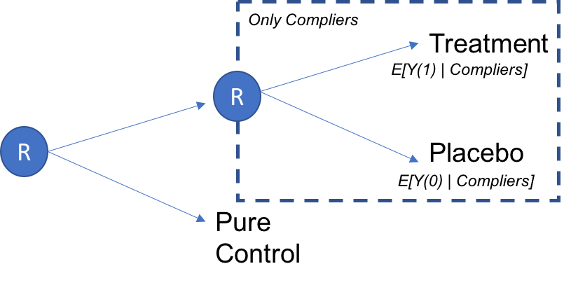

Two-Stage Placebo Design

In placebo designs, we assign subjects to one of three conditions. In the pure control condition ($Z_i=0$), both compliers and never takers reveal their untreated potential outcomes and we cannot identify the subject’s type. In the placebo control ($Z_i=1$) and treatment ($Z_i=2$) conditions, we can identify types (compliers and never takers). The move in such designs is to “screen out” never takers and “eliminate the noise generated by [their] presence in both treatment and control groups” (FEDAI:162). Typically then, such designs produce two estimates of the CACE:

**Method 1**:

$$\begin{equation}
\hat{CACE} = \frac{\hat{ITT_Y}}{\hat{ITT_D}} = \frac{E[Y_i|Z=2] -
E[Y_i|Z=0]}{E[D_i|Z=2] - E[D_i|Z=0]}
\end{equation}$$

**Method 2:**
$$\begin{equation}
\hat{CACE} = E[Y_i(Z=2,D=1)|C] - E[Y_i(Z=1,D=0)|C]
\end{equation}$$

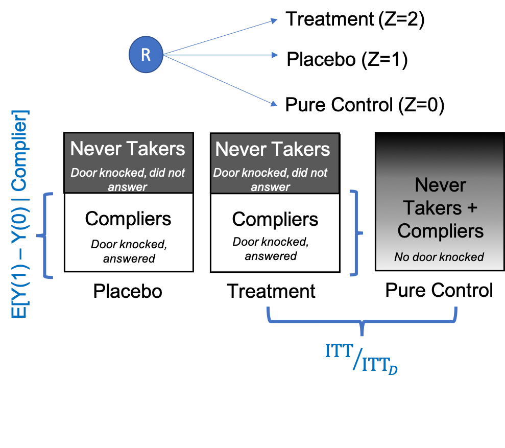

Method 2: Identifying Compliers and the CACE

## Notes About Placebo Designs

1. The difference-in-means estimator used in Method 2 is unbiased, while the ratio estimator used in Method 1 is biased. Both estimators are consistent.
2. Placebo designs are “over-identified” because the same data produce two estimates of the complier average causal effect. (**Note:** A design is `just identified` when the data and assumptions produce only one estimate of the quantity of interest.)
3. Gerber and Green note, “care must be taken to avoid two sources of bias: the placebo message may affect outcomes, and the placebo Compliers may not be the same as the treatment Compliers.” (FEDAI: 163)
4. Gerber and Green show that when compliance is greater than 50% ($ITT_D > 0.5$), Method 1 (larger sample with never takers) produces more precise estimates than Method 2 (placebo design with smaller sample and only complier). For more, see p.162 in FEDAI.